# AM11 Recommendation Systems - Individual Assignment

Zervaan Borok

5/12/2021

[figure not shown]

# Introduction and GroupLens Research Data

This data set (ml-latest) describes 5-star rating and free-text tagging activity from MovieLens, a movie recommendation service. It contains 27753444 ratings and 1108997 tag applications across 58098 movies. These data were created by 283228 users between January 09, 1995 and September 26, 2018. This data set was generated on September 26, 2018.

Users were selected at random for inclusion. All selected users had rated at least 1 movies. No demographic information is included. Each user is represented by an id, and no other information is provided.

Relevant data for this assignment are contained in the files movies.csv and ratings.csv. More details about the contents and use of all these files are available at the following url. This and other GroupLens data sets are publicly available for download at [http://grouplens.org/datasets/].

# Assignment

The task here is to work with the uploaded data and build a movie recommendation system. By the end of the analysis you will be asked to propose a Recommendation System for a movie watching platform like Netflix. You will need to use your analysis and findings to justify your proposed solution.

## Load Required Libraries and Read in Data

```r
# Load required libraries

library(recommenderlab)
library(ggplot2)
library(data.table)
library(reshape2)
library(dplyr)
library(factoextra)
```

```r
# Read in data

rm(list = ls())
movieData <- fread(input = "C:/Users/zerva/OneDrive/Documents/R Scipts LBS/am10.mam2022/Individual_assignment_1/ml-latest/movies.csv", stringsAsFactors=FALSE)
ratingData <- fread(input = "C:/Users/zerva/OneDrive/Documents/R Scipts LBS/am10.mam2022/Individual_assignment_1/ml-latest/ratings.csv", select = c(1:3))
```

## Step 1 - Exploratory Analysis

```r
# Dataframe reduction

set.seed(1)

# Find list of unique userIds
uniqueUsers <- unique(ratingData$userId)

# Identify location of 10,000 randomly chosen users
locationOfSampleUsers <- which(ratingData$userId %in% sample(uniqueUsers, 1e4, replace=FALSE))

# Take a subset of 10,000 users chosen in above lines
ratingData2 <- ratingData[locationOfSampleUsers,]
ratingData <- ratingData2

# Only select movies which we have a rating for
movieData2 <- movieData[which(movieData$movieId %in% unique(ratingData$movieId)),]
movieData <- movieData2

# Delete files no longer necessary for analysis
rm(movieData2, ratingData2, uniqueUsers, locationOfSampleUsers)
```

### Data Cleaning

```r
# Remove repeats in rating data

repeatMovies <- names(which(table(movieData$title) > 1))
removeRows <- integer()
for(i in repeatMovies){
  repeatMovieLoc <- which(movieData$title == i)
  tempGenre <- paste(movieData$genres[repeatMovieLoc], collapse="|")
  tempGenre <- paste(unique(unlist(strsplit(tempGenre, split = "\\|")[[1]])), collapse = "|")
  movieData$genres[repeatMovieLoc[1]] <- tempGenre
  removeRows <- c(removeRows, repeatMovieLoc[-1])

  repeatMovieIdLoc <- which(ratingData$movieId %in% movieData$movieId[removeRows])
  ratingData$movieId[repeatMovieIdLoc] <- movieData$movieId[repeatMovieLoc[1]]
}
movieData$movieId[removeRows]
```

```
##  [1] 151797 114240 128862  67459 122940 144426 144606 168634 180205  65665
## [11] 128991 181751  26982 168358  64997
```

```r
movieData <- movieData[-removeRows,]
movieData[movieData$title == repeatMovies[1],]
```

```
##    movieId             title                                genres
## 1:  136696 Absolution (2015) Action|Adventure|Crime|Thriller|Drama
```

```r
movieData[movieData$title == repeatMovies[2],]
```

```
##    movieId          title                                              genres
## 1:     588 Aladdin (1992) Adventure|Animation|Children|Comedy|Musical|Fantasy
```

```r
rm(i, removeRows, repeatMovieIdLoc, repeatMovieLoc, repeatMovies, tempGenre)
```

```r
# There is a risk that the same user has rated a movie multiple times - we will take the best rating

rating_data1 <- aggregate(x = ratingData, by = list(ratingData$userId, ratingData$movieId), FUN = max)
ratingData <- rating_data1[,-c(1,2)]
rm(rating_data1)
length(unique(ratingData$movieId))
```

```
## [1] 21106
```

```r
length(unique(movieData$movieId))
```

```
## [1] 21106
```

```r
# These movies were not rated by any user. We ought to remove these from movieData or, ignore for now
no_ratings <- setdiff(unique(movieData$movieId), unique(ratingData$movieId))
no_ratings
```

```
## integer(0)
```

```r
# Quick check of data we have loaded and cleaned

str(movieData)
```

```
## Classes 'data.table' and 'data.frame':   21106 obs. of  3 variables:
##  $ movieId: int  1 2 3 4 5 6 7 8 9 10 ...
##  $ title  : chr  "Toy Story (1995)" "Jumanji (1995)" "Grumpier Old Men (1995)" "Waiting to Exhale (1995)" ...
##  $ genres : chr  "Adventure|Animation|Children|Comedy|Fantasy" "Adventure|Children|Fantasy" "Comedy|Romance" "Comedy|Drama|Romance" ...
##  - attr(*, ".internal.selfref")=<externalptr>
```

```r
summary(movieData)
```

```
##     movieId          title              genres
##  Min.   :     1   Length:21106       Length:21106
##  1st Qu.:  5601   Class :character   Class :character
##  Median : 57527   Mode  :character   Mode  :character
##  Mean   : 66568
##  3rd Qu.:114691
##  Max.   :193857
```

```r
head(movieData)
```

```
##    movieId                              title
## 1:       1                   Toy Story (1995)
## 2:       2                     Jumanji (1995)
## 3:       3            Grumpier Old Men (1995)
## 4:       4           Waiting to Exhale (1995)
## 5:       5 Father of the Bride Part II (1995)
## 6:       6                        Heat (1995)
##                                         genres
## 1: Adventure|Animation|Children|Comedy|Fantasy
## 2:                  Adventure|Children|Fantasy
## 3:                              Comedy|Romance
## 4:                        Comedy|Drama|Romance
## 5:                                      Comedy
## 6:                       Action|Crime|Thriller
```

```r
summary(ratingData)
```

```
##      userId          movieId           rating
##  Min.   :    15   Min.   :     1   Min.   :0.500
##  1st Qu.: 71968   1st Qu.:  1091   1st Qu.:3.000
##  Median :146809   Median :  2710   Median :3.500
##  Mean   :144137   Mean   : 18758   Mean   :3.533
##  3rd Qu.:214037   3rd Qu.:  7154   3rd Qu.:4.000
##  Max.   :283219   Max.   :193857   Max.   :5.000
```

```r
head(ratingData)
```

```
##   userId movieId rating
## 1     15       1    4.0
## 2    368       1    4.5
## 3    583       1    4.5
## 4    702       1    5.0
## 5    716       1    4.0
## 6    797       1    3.0
```

```r
# Construct genre list

list_genre <- c("Action", "Adventure", "Animation", "Children",
                "Comedy", "Crime","Documentary", "Drama", "Fantasy",
                "Film-Noir", "Horror", "Musical", "Mystery","Romance",
                "Sci-Fi", "Thriller", "War", "Western")
```

```r
# Construct genre matrix

 genre_mat <- data.frame(matrix(0, nrow = nrow(movieData), ncol = length(list_genre)))
 colnames(genre_mat) <- list_genre

 for(index in 1:nrow(genre_mat)) {
  castRowIndex <- which(list_genre %in% unlist(strsplit(movieData$genres[index], split = "[|]")))
   genre_mat[index, castRowIndex] <- 1
 }
 genre_mat <- apply(genre_mat, 2, as.integer)
 dim(genre_mat)
```

```
## [1] 21106    18
```

```r
 rm(castRowIndex, index)

 str(genre_mat)
```

```
##  int [1:21106, 1:18] 0 0 0 0 0 1 0 0 1 1 ...
##  - attr(*, "dimnames")=List of 2
##   ..$ : NULL
##   ..$ : chr [1:18] "Action" "Adventure" "Animation" "Children" ...
```

```r
 View(genre_mat)

 searchMatrix <- data.frame(cbind(movieData[,1:2], genre_mat[]))
 head(searchMatrix)
```

```
##   movieId                              title Action Adventure Animation
## 1       1                   Toy Story (1995)      0         1         1
## 2       2                     Jumanji (1995)      0         1         0
## 3       3            Grumpier Old Men (1995)      0         0         0
## 4       4           Waiting to Exhale (1995)      0         0         0
## 5       5 Father of the Bride Part II (1995)      0         0         0
## 6       6                        Heat (1995)      1         0         0
##   Children Comedy Crime Documentary Drama Fantasy Film.Noir Horror Musical
## 1        1      1     0           0     0       1         0      0       0
## 2        1      0     0           0     0       1         0      0       0
## 3        0      1     0           0     0       0         0      0       0
## 4        0      1     0           0     1       0         0      0       0
## 5        0      1     0           0     0       0         0      0       0
## 6        0      0     1           0     0       0         0      0       0
##   Mystery Romance Sci.Fi Thriller War Western
## 1       0       0      0        0   0       0
## 2       0       0      0        0   0       0
## 3       0       1      0        0   0       0
## 4       0       1      0        0   0       0
## 5       0       0      0        0   0       0
## 6       0       0      0        1   0       0
```

```r
 #searchMatrix <- as(searchMatrix, "binaryRatingMatrix")
#searchMatrix
# rm(searchMatrix)
```

### Ratings Matrix

```r
# Create Ratings Matrix

ratingMatrix <- dcast(ratingData, userId~movieId, value.var = "rating", na.rm=TRUE)

# UserIds as rows and MovieIds as columns
ratingMatrix <- as.matrix(ratingMatrix[,-1]) # Remove userIds
dim(ratingMatrix) # User-item matrix
```

```
## [1] 10000 21106
```

```r
setdiff(movieData$movieId, as.integer(colnames(ratingMatrix)))
```

```
## integer(0)
```

```r
# Quick check to see if we still have same set of movies
ratingMatrix <- as(ratingMatrix, "realRatingMatrix")
ratingMatrix
```

```
## 10000 x 21106 rating matrix of class 'realRatingMatrix' with 962132 ratings.
```

```r
# Convert rating matrix into a recommenderlab sparse matrix
recommendation_model <- recommenderRegistry$get_entries(dataType = "realRatingMatrix")
names(recommendation_model)
```

```
##  [1] "HYBRID_realRatingMatrix"       "ALS_realRatingMatrix"
##  [3] "ALS_implicit_realRatingMatrix" "IBCF_realRatingMatrix"
##  [5] "LIBMF_realRatingMatrix"        "POPULAR_realRatingMatrix"
##  [7] "RANDOM_realRatingMatrix"       "RERECOMMEND_realRatingMatrix"
##  [9] "SVD_realRatingMatrix"          "SVDF_realRatingMatrix"
## [11] "UBCF_realRatingMatrix"
```

```r
lapply(recommendation_model, "[[", "description")
```

```
## $HYBRID_realRatingMatrix
## [1] "Hybrid recommender that aggegates several recommendation strategies using weighted averages."
##
## $ALS_realRatingMatrix
## [1] "Recommender for explicit ratings based on latent factors, calculated by alternating least squares algorithm."
##
## $ALS_implicit_realRatingMatrix
## [1] "Recommender for implicit data based on latent factors, calculated by alternating least squares algorithm."
##
## $IBCF_realRatingMatrix
## [1] "Recommender based on item-based collaborative filtering."
##
## $LIBMF_realRatingMatrix
## [1] "Matrix factorization with LIBMF via package recosystem (https://cran.r-project.org/web/packages/recosystem/vignettes/introduction.html)."
##
## $POPULAR_realRatingMatrix
## [1] "Recommender based on item popularity."
##
## $RANDOM_realRatingMatrix
## [1] "Produce random recommendations (real ratings)."
##
## $RERECOMMEND_realRatingMatrix
## [1] "Re-recommends highly rated items (real ratings)."
##
## $SVD_realRatingMatrix
## [1] "Recommender based on SVD approximation with column-mean imputation."
##
## $SVDF_realRatingMatrix
## [1] "Recommender based on Funk SVD with gradient descend (https://sifter.org/~simon/journal/20061211.html)."
##
## $UBCF_realRatingMatrix
## [1] "Recommender based on user-based collaborative filtering."
```

```r
recommendation_model$IBCF_realRatingMatrix$parameters
```

```
## $k
## [1] 30
##
## $method
## [1] "Cosine"
##
## $normalize
## [1] "center"
##
## $normalize_sim_matrix
## [1] FALSE
##
## $alpha
## [1] 0.5
##
## $na_as_zero
## [1] FALSE
```

### Heatmaps of Unfiltered Data

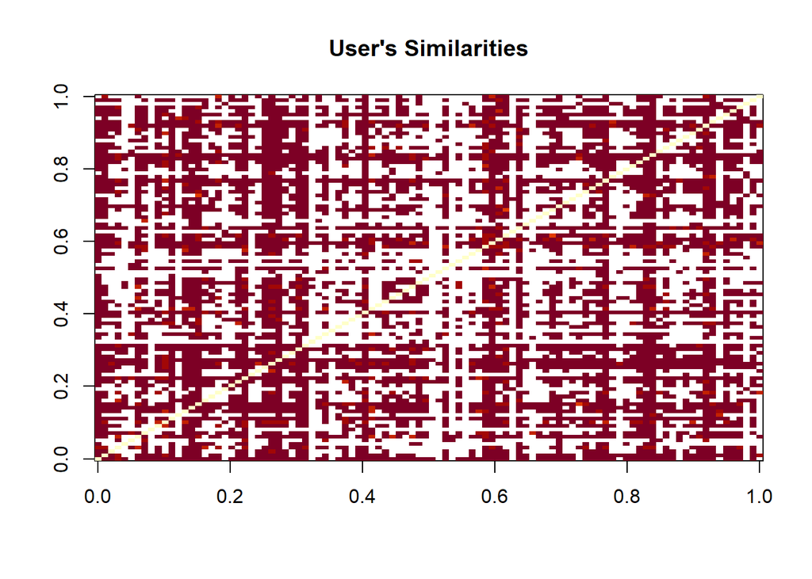

```r
# User Similarities

user_similarity <- similarity(ratingMatrix[1:100, ],
                             method = "cosine",
                             which = "users")
# as.matrix(user_similarity)
image(as.matrix(user_similarity), main = "User's Similarities")
```

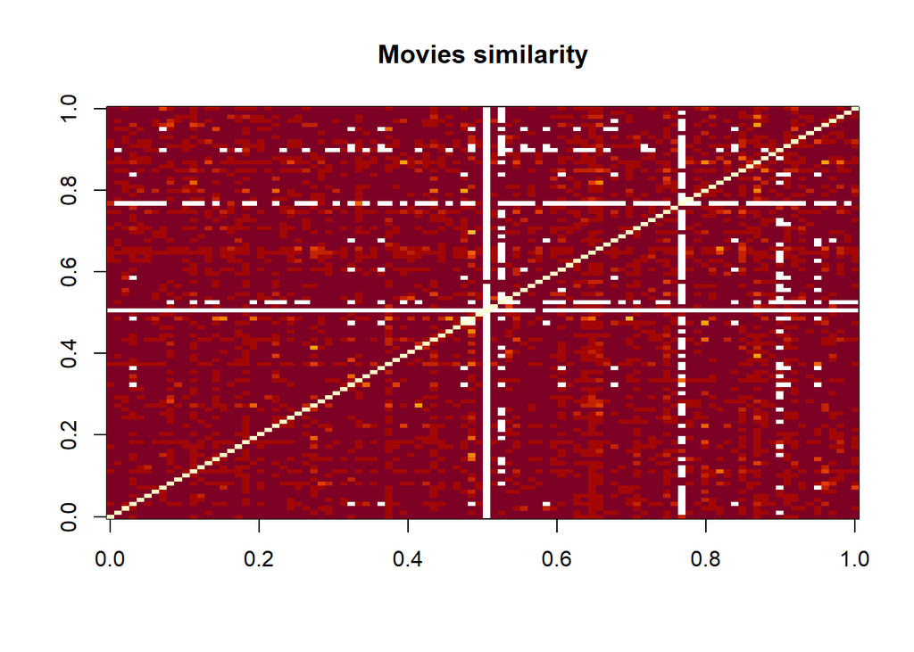

```r
# Movie Similarities

movie_similarity <- similarity(ratingMatrix[, 1:100],
                               method = "cosine",
                               which = "items")
# as.matrix(movie_similarity)
image(as.matrix(movie_similarity), main = "Movies similarity")
```

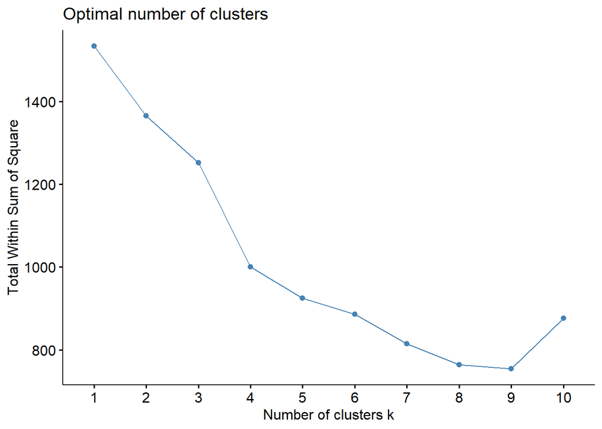

```r
# Movie Similarities

searchMatrix3 <- na.omit(searchMatrix)

rownames(searchMatrix3) <- searchMatrix3$title

searchMatrix3 <- searchMatrix3[,-c(1,2)]

fviz_nbclust(searchMatrix3[1:1000, ], kmeans, method = "wss")
```

```r
km <- kmeans(searchMatrix3[1:100, ], centers = 9, nstart = 25)

km
```

```
## K-means clustering with 9 clusters of sizes 6, 11, 5, 5, 24, 16, 19, 6, 8
##
## Cluster means:
##       Action  Adventure Animation  Children    Comedy      Crime Documentary
## 1 0.00000000 1.00000000 0.3333333 1.0000000 0.3333333 0.00000000         0.0
## 2 0.00000000 0.00000000 0.0000000 0.2727273 1.0000000 0.09090909         0.0
## 3 0.40000000 0.00000000 0.0000000 0.0000000 0.0000000 0.00000000         0.6
## 4 1.00000000 1.00000000 0.0000000 0.0000000 0.0000000 0.00000000         0.0
## 5 0.04166667 0.08333333 0.0000000 0.1250000 0.0000000 0.20833333         0.0
## 6 0.00000000 0.00000000 0.0625000 0.0625000 0.3125000 0.06250000         0.0
## 7 0.52631579 0.00000000 0.0000000 0.0000000 0.1578947 0.36842105         0.0
## 8 0.00000000 0.00000000 0.0000000 0.0000000 1.0000000 0.00000000         0.0
## 9 0.00000000 0.25000000 0.0000000 0.0000000 0.8750000 0.12500000         0.0
##       Drama    Fantasy Film.Noir     Horror Musical    Mystery Romance
## 1 0.0000000 0.66666667         0 0.00000000  0.0000 0.00000000     0.0
## 2 0.0000000 0.00000000         0 0.09090909  0.0000 0.00000000     0.0
## 3 0.0000000 0.00000000         0 0.00000000  0.0000 0.00000000     0.0
## 4 0.2000000 0.20000000         0 0.00000000  0.0000 0.00000000     0.2
## 5 1.0000000 0.04166667         0 0.00000000  0.0000 0.08333333     0.0
## 6 1.0000000 0.00000000         0 0.00000000  0.0625 0.00000000     1.0
## 7 0.4210526 0.00000000         0 0.15789474  0.0000 0.21052632     0.0
## 8 1.0000000 0.00000000         0 0.00000000  0.0000 0.00000000     0.0
## 9 0.0000000 0.00000000         0 0.12500000  0.0000 0.00000000     1.0
##       Sci.Fi  Thriller        War Western
## 1 0.00000000 0.0000000 0.00000000       0
## 2 0.00000000 0.0000000 0.00000000       0
## 3 0.00000000 0.0000000 0.00000000       0
## 4 0.00000000 0.4000000 0.00000000       0
## 5 0.08333333 0.0000000 0.08333333       0
## 6 0.00000000 0.0000000 0.00000000       0
## 7 0.15789474 1.0000000 0.00000000       0
## 8 0.00000000 0.1666667 0.00000000       0
## 9 0.00000000 0.0000000 0.00000000       0
##
## Clustering vector:
##                                                                Toy Story (1995)
##                                                                               1
##                                                                  Jumanji (1995)
##                                                                               1
##                                                         Grumpier Old Men (1995)
```

[output cut: 190 more lines]

```
##                                                                               3
##                                                                City Hall (1996)
##                                                                               7
##                                                            Bottle Rocket (1996)
##                                                                               9
##
## Within cluster sum of squares by cluster:
## [1]  4.0000000  4.0000000  2.4000000  3.6000000 15.8333333  7.1875000 24.5263158
## [8]  0.8333333  4.1250000
##  (between_SS / total_SS =  59.5 %)
##
## Available components:
##
## [1] "cluster"      "centers"      "totss"        "withinss"     "tot.withinss"
## [6] "betweenss"    "size"         "iter"         "ifault"
```

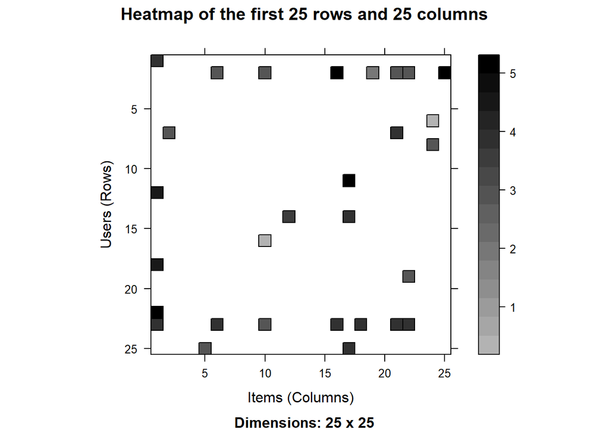

```r
# Heatmap of the first 25 rows and 25 columns

image(ratingMatrix[1:25, 1:25], axes = FALSE, main = "Heatmap of the first 25 rows and 25 columns")
```

### Frequency of Movie Ratings

```r
# Create a count of movie ratings

rating_values <- as.vector(ratingMatrix@data)
sort(unique(rating_values)) # extracting unique ratings
```

```
##  [1] 0.0 0.5 1.0 1.5 2.0 2.5 3.0 3.5 4.0 4.5 5.0
```

```r
Table_of_Ratings <- table(rating_values)
Table_of_Ratings
```

```
## rating_values
##         0       0.5         1       1.5         2       2.5         3       3.5
## 210097868     16511     29342     14241     63185     47431    193280    118948
##         4       4.5         5
##    254816     83188    141190
```

### Aggregation of Views by Movie

```r
# Create data frame of movies and corresponding number of views

movie_views <- colCounts(ratingMatrix) # count views for each movie
table_views <- data.frame(movie = names(movie_views),
                          views = movie_views) # create dataframe of views

table_views$movie <- as.numeric(table_views$movie)

table_views1 <- merge(movieData[,1:2], table_views, by.x = 'movieId', by.y = 'movie')
table_views2 <- table_views1[order(table_views1$views, decreasing = TRUE), ] # sort by number of views
table_views <- table_views2

head(table_views)
```

```
##    movieId                                     title views
## 1:     318          Shawshank Redemption, The (1994)  3421
## 2:     356                       Forrest Gump (1994)  3419
## 3:     296                       Pulp Fiction (1994)  3229
## 4:     593          Silence of the Lambs, The (1991)  3054
## 5:    2571                        Matrix, The (1999)  2981
## 6:     260 Star Wars: Episode IV - A New Hope (1977)  2876
```

```r
rm(table_views1, table_views2)
```

### Distribution of Movie Views

```r
# Get distribution of views by movie

avg <- summary(table_views$views)[4]

std <- sd(table_views$views)

summary(table_views$views)
```

```
##    Min. 1st Qu.  Median    Mean 3rd Qu.    Max.
##    1.00    1.00    3.00   45.59   19.00 3421.00
```

```r
std
```

```
## [1] 159.8889
```

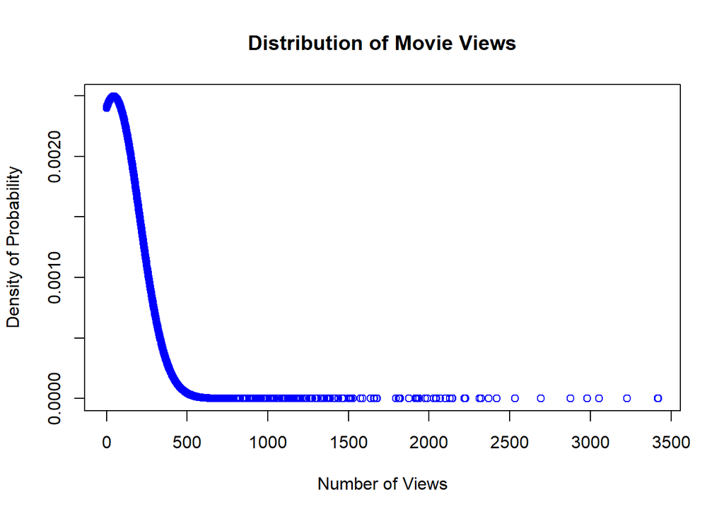

```r
x <- table_views$views

y <- dnorm(x, mean = avg, sd = std)

plot(x,y, main = "Distribution of Movie Views", col = "blue", xlab = "Number of Views", ylab = "Density of Probability")
```

### Plot of Top 10 Movies by Views

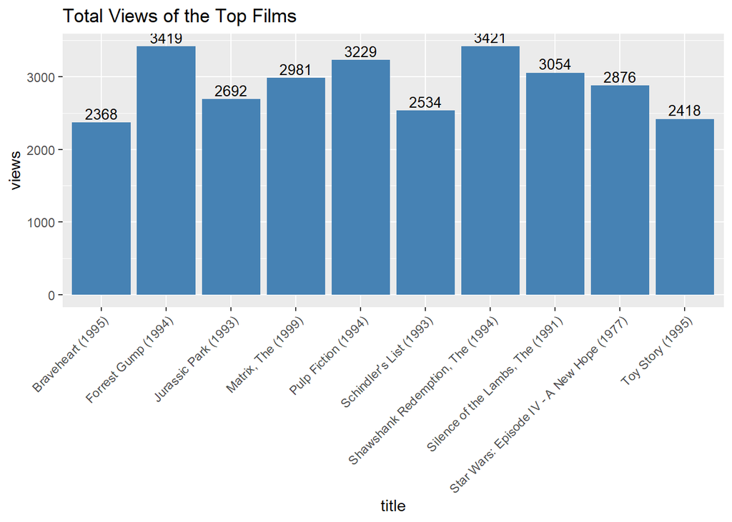

```r
# Bar Chart of total views of the top films

library(ggplot2)

ggplot(table_views[1:10, ], aes(x = title, y = views)) +
  geom_bar(stat="identity", fill = 'steelblue') +
  geom_text(aes(label=views), vjust=-0.3, size=3.5) +
  theme(axis.text.x = element_text(angle = 45, hjust = 1)) +
  ggtitle("Total Views of the Top Films")
```

### Filter Data

```r
# Filter ratings matrix

movie_ratings <- ratingMatrix[rowCounts(ratingMatrix) > 50,
                              colCounts(ratingMatrix) > 50]
movie_ratings
```

```
## 3791 x 3122 rating matrix of class 'realRatingMatrix' with 721915 ratings.
```

### Plots, Heatmaps, and Distributions of Filtered Data

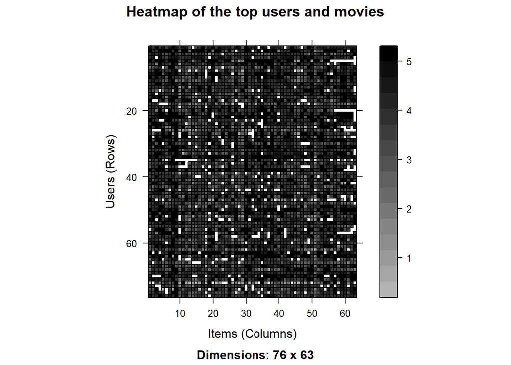

```r
# Heatmap of the top users and movies

minimum_movies<- quantile(rowCounts(movie_ratings), 0.98)
minimum_users <- quantile(colCounts(movie_ratings), 0.98)
## This is our user-item matrix - only for common users and items ##
image(movie_ratings[rowCounts(movie_ratings) > minimum_movies,
                    colCounts(movie_ratings) > minimum_users],
      main = "Heatmap of the top users and movies")
```

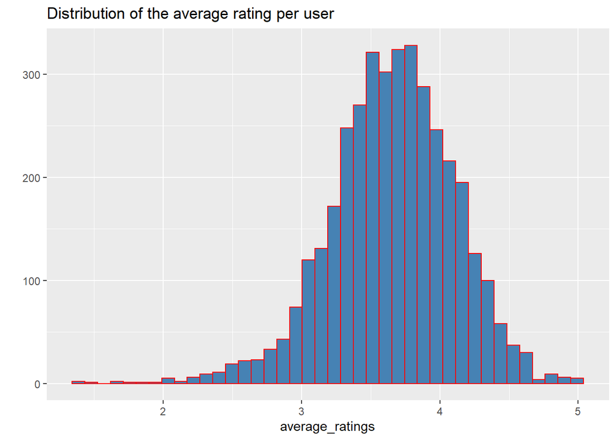

```r
# Distribution of Average Rating per User

average_ratings <- rowMeans(movie_ratings)
qplot(average_ratings, fill=I("steelblue"), col=I("red"), bins = 40) +
  ggtitle("Distribution of the average rating per user")
```

```r
mean(average_ratings)
```

```
## [1] 3.657523
```

```r
tab <- table(average_ratings > 3.25, average_ratings < 4.5)[2,2]
tab
```

```
## [1] 3079
```

```r
total <- sum(table(average_ratings > 3.25, average_ratings < 4.5))
perc <- (tab/total)*100
perc
```

```
## [1] 81.21868
```

```r
# Plot of normalized rating data

normalized_ratings <- normalize(movie_ratings)
sum(rowMeans(normalized_ratings) > 0.00001)
```

```
## [1] 0
```

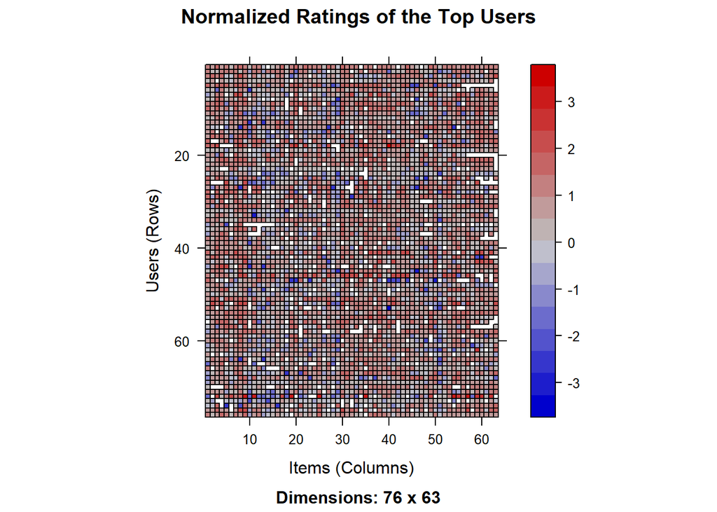

```r
image(normalized_ratings[rowCounts(normalized_ratings) > minimum_movies,
                         colCounts(normalized_ratings) > minimum_users],
      main = "Normalized Ratings of the Top Users")
```

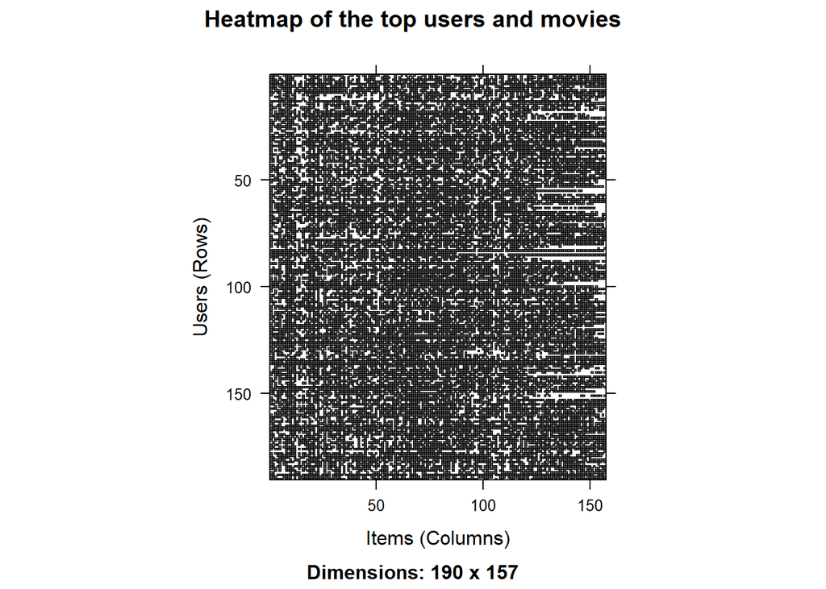

```r
# Heatmap of the top users and movies with minimum rating filter

binary_minimum_movies <- quantile(rowCounts(movie_ratings), 0.95)
binary_minimum_users <- quantile(colCounts(movie_ratings), 0.95)
#movies_watched <- binarize(movie_ratings, minRating = 1)
good_rated_films <- binarize(movie_ratings, minRating = 3)
image(good_rated_films[rowCounts(movie_ratings) > binary_minimum_movies,
                       colCounts(movie_ratings) > binary_minimum_users],
      main = "Heatmap of the top users and movies")
```

### Questions for Step 1:

**(i) Can you spot any issues or gaps in the data that could influence results from a Recommendation System?**

There are movies that appear to have duplicate entries as well as users who have rated the same movie more than once. These observations will likely influence the results of any Recommendation System.

**(ii) In an ideal world, what additional data would you like to analyse?**

In addition to the data provided, I would ideally like to have some more information about both the movies and the users. With respect to the movies, I would want to know how well each one performed at the box office as this is typically a good measure for evaluating the appeal of a movie to the general population. With regards to the users, I believe obtaining information pertaining to age and gender would be beneficial to this analysis. Some genres tend to be more popular among females and others among males. Additionally, different age ranges tend to gravitate towards different genres of movies. For example, young children will likely have very different tastes in movies when compared to middle-aged adults.

**(iii) How does the count of views (# of ratings) vary across your list of movies?**

The count of views has a range from 1.00 to 3421.00 with a median view count of 3.00 and a mean view count of 45.59. The standard deviation is 159.89 views and the distribution is heavily right-skewed.

**(iv) How are the user provided ratings (of movies) distributed?**

Over 81% of average user ratings fall within the range of (3.25, 4.5) and the mean rating across the entire averaged data set is 3.66.

**(v) How similar are the 100 most frequent movies or users to each other?**

In general, the users and movies are neither very similar nor very dissimilar. Some are extremely similar while others are extremely dissimilar. Within this data set, it is hard to make a broad-sweeping statement about this subject.

## Step 2 - Building recommendation systems

### Questions for Step 2:

**(i) When do Collaborative Filtering methods work best and when do they fail?**

Collaborative filtering methods work best when we have sufficient data of past interactions between users and a large basket of items and when there is enough data to establish some degree of similarity between users. Collaborative filtering methods tend to fail when new items are added to the ‘basket’ as it may not be clear which established rules to apply. They also struggle when introduced to a brand new user as there is no prior information on this user. Additionally, irregular users may not generate enough data to determine similarities. They will also fail if there are too many observations that are classified as ‘on-the-fence’. Finally, collaborative filtering methods can be computationally intensive.

**(ii) How do we build a recommendation system for infrequent users or new/rare movies?**

We use content based methods because we have no prior information on new users or new/rare movies.

**(iii) Which Recommendation Systems would you propose building on this data?**

I would recommend building at least one memory based approach and one model based approach for this data set. To be thorough however, I would recommend building two different memory based approaches and two model based approaches as some collaborative filtering methods work better than others on certain data sets. With respect to the memory-based approaches, I would suggest creating a User-Based-Collaborative-Filtering (UBCF) model and an Item-Based-Collaborative-Filtering (IBCF) model. With regard to model-based approaches, I would suggest creating a Matrix Factorisation Collaborative Filtering model as well as experimenting with a singular value decomposition (SVD) model.

**(vi) Can you generate recommendations like ‘users like you watched…’ and ‘movies similar to this…’?**

Yes, I generated recommendations such as the ones above using all four models I created in the code below. The four models are as follows:

1. Item Based Collaborative Filtering (IBCF)
2. User Based Collaborative Filtering (UBCF)
3. Single Value Decomposition (SVD)
4. Model Based Collaborative Filtering using Matrix Factorisation (LIBMF)

### Basic Item Based Collaborative Filtering (IBCF) Model

```r
# Here we split our sample into train and test. We intend to train our model on 80% of the data and test the model on the remaining 20%

sampled_data<- sample(x = c(TRUE, FALSE),
                      size = nrow(movie_ratings),
                      replace = TRUE,
                      prob = c(0.8, 0.2))
training_data <- movie_ratings[sampled_data, ]
testing_data <- movie_ratings[!sampled_data, ]

recommendation_system <- recommenderRegistry$get_entries(dataType ="realRatingMatrix")
recommendation_system$IBCF_realRatingMatrix$parameters
```

```
## $k
## [1] 30
##
## $method
## [1] "Cosine"
##
## $normalize
## [1] "center"
##
## $normalize_sim_matrix
## [1] FALSE
##
## $alpha
## [1] 0.5
##
## $na_as_zero
## [1] FALSE
```

```r
## Basic IBCF

recommen_model <- Recommender(data = training_data,
                              method = "IBCF",
                              parameter = list(k = 30))
recommen_model
```

```
## Recommender of type 'IBCF' for 'realRatingMatrix'
## learned using 3011 users.
```

```r
class(recommen_model)
```

```
## [1] "Recommender"
## attr(,"package")
## [1] "recommenderlab"
```

#### Model Inspection

```r
# Model Info

 model_info <- getModel(recommen_model)
 class(model_info$sim)
```

```
## [1] "dgCMatrix"
## attr(,"package")
## [1] "Matrix"
```

```r
 dim(model_info$sim)
```

```
## [1] 3122 3122
```

```r
 top_items <- 20
```

```r
# This is the number of items (movies) we are using. Most popular movies

sum_rows <- rowSums(model_info$sim > 0)
table(sum_rows)
```

```
## sum_rows
##   30
## 3122
```

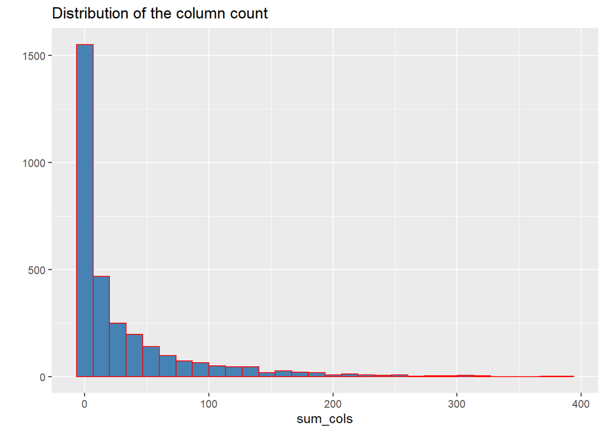

```r
# Distribution of the column count

sum_cols <- colSums(model_info$sim > 0)
qplot(sum_cols, fill=I("steelblue"), col=I("red"))+ ggtitle("Distribution of the column count")
```

#### Model Prediction

```r
# Predicted Recommendations

top_recommendations <- 5 # the number of items to recommend to each user
predicted_recommendations <- predict(object = recommen_model,
                                     newdata = testing_data,
                                     n = top_recommendations)
predicted_recommendations
```

```
## Recommendations as 'topNList' with n = 5 for 780 users.
```

```r
user1 <- predicted_recommendations@items[[12]] # recommendation for the twelfth user
movies_user1 <- predicted_recommendations@itemLabels[user1]
movieData$title[movieData$movieId %in% movies_user1]
```

```
## [1] "Grumpier Old Men (1995)"      "Waiting to Exhale (1995)"
## [3] "Heat (1995)"                  "Nixon (1995)"
## [5] "Sense and Sensibility (1995)"
```

### Similar Movies Model

```r
# Genre matrix analysis

searchMatrix1 <- searchMatrix[,-2]

searchMatrix1 <- as.matrix(searchMatrix1)


searchMatrix11 <- as(searchMatrix1, "binaryRatingMatrix")


sampled_data1<- sample(x = c(TRUE, FALSE),
                      size = nrow(searchMatrix11),
                      replace = TRUE,
                      prob = c(0.8, 0.2))
training_data1 <- searchMatrix11[sampled_data1, ]
testing_data1 <- searchMatrix11[!sampled_data1, ]

recommendation_system1 <- recommenderRegistry$get_entries(dataType ="binaryRatingMatrix")
recommendation_system1$IBCF_binaryRatingMatrix$parameters
```

```
## $k
## [1] 30
##
## $method
## [1] "Jaccard"
##
## $normalize_sim_matrix
## [1] FALSE
##
## $alpha
## [1] 0.5
```

```r
recommen_model1 <- Recommender(data = training_data1,
                              method = "IBCF",
                              parameter = list(k = 30))
recommen_model1
```

```
## Recommender of type 'IBCF' for 'binaryRatingMatrix'
## learned using 16932 users.
```

```r
class(recommen_model1)
```

```
## [1] "Recommender"
## attr(,"package")
## [1] "recommenderlab"
```

#### Model Prediction

```r
# Predicted Recommendations

top_recommendations1 <- 10 # the number of items to recommend to each user
predicted_recommendations1 <- predict(object = recommen_model1,
                                     newdata = testing_data1,
                                      n = top_recommendations1)
predicted_recommendations1
```

```
## Recommendations as 'topNList' with n = 10 for 4174 users.
```

```r
# Similar Movies

user15 <- predicted_recommendations1@items[[15]] # recommendation for the fifteenth user
#movies15 <- predicted_recommendations1@itemLabels[user15]
movieData$title[movieData$movieId %in% user15]
```

```
##  [1] "Waiting to Exhale (1995)"           "Father of the Bride Part II (1995)"
##  [3] "Heat (1995)"                        "Sabrina (1995)"
##  [5] "GoldenEye (1995)"                   "Dracula: Dead and Loving It (1995)"
##  [7] "Cutthroat Island (1995)"            "Casino (1995)"
##  [9] "Sense and Sensibility (1995)"       "Four Rooms (1995)"
```

### User Based Collaborative Filtering (UBCF)

```r
## User Based Collaborative Filtering

set.seed(1)
e <- evaluationScheme(movie_ratings, method="split", train=0.8, given=-5)

# Creation of the model - U(ser) B(ased) C(ollaborative) F(iltering)
recommen_model_UBCF <- Recommender(movie_ratings, method = "UBCF",
                         parameter=list(normalize = "center", method="Cosine", nn=25))

#Making predictions
prediction <- predict(recommen_model_UBCF, movie_ratings[1:25, ], type="ratings")
as(prediction, "matrix")[,1:5]
```

```
##              1        2        3        4        5
##  [1,]       NA 3.378010 2.427961 6.703152 4.645969
##  [2,] 4.189539       NA       NA       NA       NA
##  [3,] 3.300035       NA 3.968599       NA 3.968599
##  [4,] 4.166687 2.905800 2.900942 2.919025 2.589349
##  [5,]       NA 3.797522 4.077157 5.503034 4.087195
##  [6,] 4.253445       NA       NA 3.008892       NA
##  [7,] 4.885483 4.808747 3.936266 1.241071 3.984127
##  [8,] 4.086203 4.066382 2.627920       NA       NA
##  [9,]       NA 4.256701 3.846511 3.816068 4.675376
## [10,]       NA 3.986299       NA       NA       NA
## [11,]       NA       NA 2.759900       NA 3.487708
## [12,]       NA       NA 2.554494       NA       NA
## [13,]       NA       NA 3.012035 1.088545 3.027484
## [14,]       NA 4.262995 3.733099 3.655630 3.551926
## [15,]       NA       NA       NA       NA       NA
## [16,]       NA       NA       NA       NA       NA
## [17,]       NA       NA 5.000000       NA 4.000000
## [18,]       NA 4.839662 2.980013       NA       NA
## [19,] 3.919179       NA 3.658333 1.849854 3.849854
## [20,] 3.126335 3.305525 2.800084 3.800084 3.300084
## [21,]       NA       NA       NA       NA       NA
## [22,] 4.842054 4.599553 4.503762 1.056402 3.616284
## [23,] 4.442654 4.110113 4.379879       NA 4.931609
## [24,] 3.817320 3.714286       NA       NA 3.885783
## [25,]       NA       NA 3.906805       NA 4.213770
```

#### Evaluate Model Performance with Different Numbers of Nearest Neighbors

```r
#Estimating RMSE for UBCF Using train/test split

set.seed(1)

# NN = 25
RMSE.modelUBCF <- Recommender(getData(e, "train"), method = "UBCF",
                          parameter=list(normalize = "center", method="Cosine", nn=25))

prediction_UBCF <- predict(RMSE.modelUBCF, getData(e, "known"), type="ratings")

rmse_ubcf25 <- calcPredictionAccuracy(prediction_UBCF, getData(e, "unknown"))[1]


set.seed(1)
# NN = 30
RMSE.modelUBCF <- Recommender(getData(e, "train"), method = "UBCF",
                          parameter=list(normalize = "center", method="Cosine", nn=30))

prediction_UBCF <- predict(RMSE.modelUBCF, getData(e, "known"), type="ratings")

rmse_ubcf30 <- calcPredictionAccuracy(prediction_UBCF, getData(e, "unknown"))[1]


set.seed(1)
# NN = 40
RMSE.modelUBCF <- Recommender(getData(e, "train"), method = "UBCF",
                          parameter=list(normalize = "center", method="Cosine", nn=40))

prediction_UBCF <- predict(RMSE.modelUBCF, getData(e, "known"), type="ratings")

rmse_ubcf40 <- calcPredictionAccuracy(prediction_UBCF, getData(e, "unknown"))[1]


set.seed(1)
# NN = 50
RMSE.modelUBCF <- Recommender(getData(e, "train"), method = "UBCF",
                          parameter=list(normalize = "center", method="Cosine", nn=50))

prediction_UBCF <- predict(RMSE.modelUBCF, getData(e, "known"), type="ratings")

rmse_ubcf50 <- calcPredictionAccuracy(prediction_UBCF, getData(e, "unknown"))[1]


df_1 <- c(rmse_ubcf25, rmse_ubcf30, rmse_ubcf40, rmse_ubcf50)
df_1 <- as.data.frame(df_1)

list_1 <- c("UBCF NN = 25", "UBCF NN = 30", "UBCF NN = 40", "UBCF NN = 50")

df_11 <- cbind(Model = list_1, df_1)
names(df_11)[names(df_11) == "df_1"] <- "RMSE"

df_11
```

```
##          Model     RMSE
## 1 UBCF NN = 25 1.161937
## 2 UBCF NN = 30 1.152830
## 3 UBCF NN = 40 1.130616
## 4 UBCF NN = 50 1.116314
```

#### Model Predictions for Selected User

```r
# Recommended Movie ID's for a given user UBCF

movie_ratings[410,]
```

```
## 1 x 3122 rating matrix of class 'realRatingMatrix' with 87 ratings.
```

```r
recommended.items.u410UBCF<- predict(RMSE.modelUBCF, movie_ratings[410,], n=10)
as(recommended.items.u410UBCF, "list")[[1]]
```

```
##  [1] "4015" "2371" "4280" "232"  "4903" "5945" "5954" "6620" "3882" "4823"
```

```r
# Recommended Movie Titles and Corresponding Genres for a given user UBCF

user2 <- recommended.items.u410UBCF@items[[1]]
movies_user2 <- recommended.items.u410UBCF@itemLabels[user2]
titles1 <- movieData$title[movieData$movieId %in% movies_user2]
genres1 <- movieData$genres[movieData$movieId %in% movies_user2]
combined1 <- cbind(titles1, genres1)
combined1
```

```
##       titles1                                       genres1
##  [1,] "Eat Drink Man Woman (Yin shi nan nu) (1994)" "Comedy|Drama|Romance"
##  [2,] "Fletch (1985)"                               "Comedy|Crime|Mystery"
##  [3,] "Bring It On (2000)"                          "Comedy"
##  [4,] "Dude, Where's My Car? (2000)"                "Comedy|Sci-Fi"
##  [5,] "World According to Garp, The (1982)"         "Comedy|Drama|Romance"
##  [6,] "Serendipity (2001)"                          "Comedy|Romance"
##  [7,] "In the Bedroom (2001)"                       "Drama"
##  [8,] "About Schmidt (2002)"                        "Comedy|Drama"
##  [9,] "25th Hour (2002)"                            "Crime|Drama"
## [10,] "American Splendor (2003)"                    "Comedy|Drama"
```

### Item Based Collaborative Filtering (IBCF)

```r
## Item-item collaborative Filtering

#Building model
recommen_model_IBCF <- Recommender(movie_ratings, method = "IBCF",
                     parameter=list(normalize = "center", method="Cosine", k=350))

#Making predictions
prediction <- predict(recommen_model_IBCF, movie_ratings[1:25], type="ratings")
as(prediction, "matrix")[,1:5]
```

```
##              1        2        3        4        5
##  [1,]       NA 3.633756 4.208018 2.673262 2.408018
##  [2,] 4.904788 2.854337 3.024717       NA 3.000000
##  [3,] 3.545386       NA 2.645810 2.513564 2.161056
##  [4,] 4.305630 3.038179 3.480890 2.737335 3.124605
##  [5,]       NA 3.373516 4.597228 3.811258 3.625197
##  [6,] 4.222303 3.003013 4.445830 4.000000 3.105865
##  [7,] 4.521991 2.000000 2.252104 3.956562 2.346025
##  [8,] 4.130714 2.736832 3.100771 4.159465 2.500000
##  [9,]       NA 3.283558 4.301208 4.298395 3.290272
## [10,]       NA 3.403939 3.151341 2.379678 3.040812
## [11,]       NA       NA 3.206864 3.000000 2.497216
## [12,]       NA       NA 3.425957 3.814721 3.019021
## [13,]       NA       NA 3.417009 3.460789 3.512172
## [14,]       NA 3.204113 3.307087 4.208566 3.717722
## [15,]       NA 2.981489 3.301032 3.470385 3.245094
## [16,] 4.170932       NA 2.990475       NA       NA
## [17,]       NA       NA       NA       NA       NA
## [18,]       NA 1.497162 4.000000 4.325272 1.860993
## [19,] 4.401515 2.761913 2.723608 2.492620 2.624861
## [20,] 3.844623       NA       NA 5.000000 5.000000
## [21,]       NA 3.057638 3.375205 1.534031 2.721290
## [22,] 4.584883 3.657295 3.421728 3.716222 3.619912
## [23,] 4.644401       NA       NA       NA       NA
## [24,] 4.154592       NA 4.500000 3.242056 2.000000
## [25,]       NA       NA 3.533187 3.763388 3.550569
```

#### Evaluate Model Performance with Different Values of K

```r
#Estimating RMSE for IBCF Using train/test split

set.seed(1)
# K = 150
RMSE.modelIBCF <- Recommender(getData(e, "train"), method = "IBCF",
                     parameter=list(normalize = "center", method="Cosine",k=150))

prediction_IBCF <- predict(RMSE.modelIBCF, getData(e, "known"), type="ratings")

rmse_ibcf150 <- calcPredictionAccuracy(prediction_IBCF, getData(e, "unknown"))[1]



set.seed(1)
# K = 350
RMSE.modelIBCF <- Recommender(getData(e, "train"), method = "IBCF",
                     parameter=list(normalize = "center", method="Cosine",k=350))

prediction_IBCF <- predict(RMSE.modelIBCF, getData(e, "known"), type="ratings")

rmse_ibcf350 <- calcPredictionAccuracy(prediction_IBCF, getData(e, "unknown"))[1]


set.seed(1)
# K = 550
RMSE.modelIBCF <- Recommender(getData(e, "train"), method = "IBCF",
                     parameter=list(normalize = "center", method="Cosine",k=550))

prediction_IBCF <- predict(RMSE.modelIBCF, getData(e, "known"), type="ratings")

rmse_ibcf550 <- calcPredictionAccuracy(prediction_IBCF, getData(e, "unknown"))[1]


set.seed(1)
# K = 750
RMSE.modelIBCF <- Recommender(getData(e, "train"), method = "IBCF",
                     parameter=list(normalize = "center", method="Cosine",k=750))

prediction_IBCF <- predict(RMSE.modelIBCF, getData(e, "known"), type="ratings")

rmse_ibcf750 <- calcPredictionAccuracy(prediction_IBCF, getData(e, "unknown"))[1]



df_2 <- c(rmse_ibcf150, rmse_ibcf350, rmse_ibcf550, rmse_ibcf750)
df_2 <- as.data.frame(df_2)

list_2 <- c("IBCF K = 150", "IBCF K = 350", "IBCF K = 550", "IBCF K = 750")

df_22 <- cbind(Model = list_2, df_2)
names(df_22)[names(df_22) == "df_2"] <- "RMSE"

df_22
```

```
##          Model      RMSE
## 1 IBCF K = 150 0.9610675
## 2 IBCF K = 350 0.9070720
## 3 IBCF K = 550 0.8696669
## 4 IBCF K = 750 0.8576683
```

#### Model Predictions for Selected User

```r
# Recommended Movie ID's for a given user IBCF

movie_ratings[410,]
```

```
## 1 x 3122 rating matrix of class 'realRatingMatrix' with 87 ratings.
```

```r
recommended.items.u410IBCF <- predict(RMSE.modelIBCF, movie_ratings[410,], n=10)
as(recommended.items.u410IBCF, "list")[[1]]
```

```
##  [1] "233"   "362"   "1238"  "4225"  "5013"  "4086"  "2857"  "57"    "45210"
## [10] "2936"
```

```r
# Recommended Movie Titles for a given user IBCF

user3 <- recommended.items.u410IBCF@items[[1]]
movies_user3 <- recommended.items.u410IBCF@itemLabels[user3]
titles2 <- movieData$title[movieData$movieId %in% movies_user3]
genres2 <- movieData$genres[movieData$movieId %in% movies_user3]
combined2 <- cbind(titles2, genres2)
combined2
```

```
##       titles2
##  [1,] "Home for the Holidays (1995)"
##  [2,] "Exotica (1994)"
##  [3,] "Jungle Book, The (1994)"
##  [4,] "Local Hero (1983)"
##  [5,] "Yellow Submarine (1968)"
##  [6,] "Sullivan's Travels (1941)"
##  [7,] "Big Easy, The (1987)"
##  [8,] "Dish, The (2001)"
##  [9,] "Gosford Park (2001)"
## [10,] "United 93 (2006)"
##       genres2
##  [1,] "Drama"
##  [2,] "Drama"
##  [3,] "Adventure|Children|Romance"
##  [4,] "Comedy"
##  [5,] "Adventure|Animation|Comedy|Fantasy|Musical"
##  [6,] "Adventure|Comedy|Romance"
##  [7,] "Action|Crime|Mystery|Romance|Thriller"
##  [8,] "Comedy"
##  [9,] "Comedy|Drama|Mystery"
## [10,] "Crime|Drama"
```

### Single Value Decomposition (SVD)

```r
## SVD collaborative Filtering

#Building model
recommen_model_SVD_0 <- Recommender(movie_ratings, method = "SVD",
                     parameter=list(normalize = "center", k=25, maxit = 2000))

#Making predictions
prediction <- predict(recommen_model_SVD_0, movie_ratings[1:25], type="ratings")
as(prediction, "matrix")[,1:5]
```

```
##              1        2        3        4        5
##  [1,]       NA 4.085833 4.018390 3.960351 3.917422
##  [2,] 4.013796 3.652336 3.613142 3.695620 3.587635
##  [3,] 2.991047       NA 3.019680 3.049485 3.017544
##  [4,] 3.582748 3.455570 3.575679 3.513431 3.531429
##  [5,]       NA 4.515594 4.456741 4.454597 4.459444
##  [6,] 4.124902 3.858840 3.993892 3.992401 3.947335
##  [7,] 4.404553 4.337770 4.386277 4.410018 4.365587
##  [8,] 3.597721 3.778392 3.837161 3.919612 3.793758
##  [9,]       NA 4.443551 4.420016 4.408113 4.420832
## [10,]       NA 3.593197 3.728962 3.756099 3.701996
## [11,]       NA       NA 3.532654 3.543755 3.508070
## [12,]       NA       NA 3.934856 3.959847 3.847066
## [13,]       NA       NA 3.700420 3.749915 3.711616
## [14,]       NA 4.095336 3.980622 3.908034 4.031884
## [15,]       NA 3.799189 3.887093 3.851214 3.880226
## [16,] 3.829120       NA 3.352488       NA       NA
## [17,]       NA 5.000000 5.000000 5.000000 5.000000
## [18,]       NA 3.486711 3.478951 3.515695 3.485273
## [19,] 3.665166 3.406396 3.490531 3.473082 3.454223
## [20,] 3.749236 3.707600 3.755297 3.736097 3.694198
## [21,]       NA 3.379613 3.338186 3.296078 3.302877
## [22,] 4.644185 4.203475 4.259064 4.240447 4.257800
## [23,] 4.384171 4.317379 4.342471 4.350029 4.327566
## [24,] 3.939422 3.846401 3.788276 3.766252 3.778829
## [25,]       NA       NA 3.920516 3.709038 3.989351
```

#### Evaluate Model Performance with Different Values of K

```r
## Estimating RMSE for SVD collaborative Filtering Using train/test split

set.seed(1)
# K = 25
recommen_model_SVD <- Recommender(getData(e, "train"), method = "SVD",
                     parameter=list(normalize = "center", k=25, maxit = 2000))

prediction_SVD <- predict(recommen_model_SVD, getData(e, "known"), type="ratings")

rmse_svd25 <- calcPredictionAccuracy(prediction_SVD, getData(e, "unknown"))[1]


set.seed(1)
# K = 50
recommen_model_SVD <- Recommender(getData(e, "train"), method = "SVD",
                     parameter=list(normalize = "center", k=50, maxit = 2000))

prediction_SVD <- predict(recommen_model_SVD, getData(e, "known"), type="ratings")
as(prediction_SVD, "matrix")[1:10,1:5]
```

```
##              1        2        3        4        5
##  [1,] 4.201567 3.582794 3.670439 3.709175 3.665471
##  [2,] 3.780721 3.790067 3.854031 3.880843 3.844756
##  [3,] 3.553646 3.596238 3.732194 3.694403 3.706613
##  [4,]       NA 3.283178 3.278635 3.265808 3.286438
##  [5,] 3.974458 3.767853 3.868103 3.801452 3.853229
##  [6,]       NA       NA 2.915325 3.044346 3.044197
##  [7,] 3.797180 3.897560       NA 3.882587 3.915169
##  [8,]       NA 4.046074 3.930819 3.921041 3.874879
##  [9,]       NA       NA 3.427199 3.465229 3.459523
## [10,]       NA 3.358218       NA 3.325184 3.324885
```

```r
rmse_svd50 <- calcPredictionAccuracy(prediction_SVD, getData(e, "unknown"))[1]


set.seed(1)
# K = 100
recommen_model_SVD <- Recommender(getData(e, "train"), method = "SVD",
                     parameter=list(normalize = "center", k=100, maxit = 2000))

prediction_SVD <- predict(recommen_model_SVD, getData(e, "known"), type="ratings")

rmse_svd100 <- calcPredictionAccuracy(prediction_SVD, getData(e, "unknown"))[1]


set.seed(1)
# K = 150
recommen_model_SVD <- Recommender(getData(e, "train"), method = "SVD",
                     parameter=list(normalize = "center", k=150, maxit = 2000))

prediction_SVD <- predict(recommen_model_SVD, getData(e, "known"), type="ratings")

rmse_svd150 <- calcPredictionAccuracy(prediction_SVD, getData(e, "unknown"))[1]


df_3 <- c(rmse_svd25, rmse_svd50, rmse_svd100, rmse_svd150)
df_3 <- as.data.frame(df_3)

list_3 <- c("SVD K = 25", "SVD K = 50", "SVD K = 100", "SVD K = 150")

df_33 <- cbind(Model = list_3, df_3)
names(df_33)[names(df_33) == "df_3"] <- "RMSE"

df_33
```

```
##         Model      RMSE
## 1  SVD K = 25 0.9011910
## 2  SVD K = 50 0.8963923
## 3 SVD K = 100 0.8944230
## 4 SVD K = 150 0.8962056
```

#### Model Predictions for Selected User

```r
# Recommended Movie ID's for a given user SVD

movie_ratings[410,]
```

```
## 1 x 3122 rating matrix of class 'realRatingMatrix' with 87 ratings.
```

```r
recommended.items.u410SVD <- predict(recommen_model_SVD, movie_ratings[410,], n=10)
as(recommended.items.u410SVD, "list")[[1]]
```

```
##  [1] "590"  "1198" "1097" "1380" "2997" "32"   "1747" "3114" "1961" "1356"
```

```r
# Recommended Movie Titles for a given user SVD

user4 <- recommended.items.u410SVD@items[[1]]
movies_user4 <- recommended.items.u410SVD@itemLabels[user4]
titles3 <- movieData$title[movieData$movieId %in% movies_user4]
genres3 <- movieData$genres[movieData$movieId %in% movies_user4]
combined3 <- cbind(titles3, genres3)
combined3
```

```
##       titles3
##  [1,] "Twelve Monkeys (a.k.a. 12 Monkeys) (1995)"
##  [2,] "Dances with Wolves (1990)"
##  [3,] "E.T. the Extra-Terrestrial (1982)"
##  [4,] "Raiders of the Lost Ark (Indiana Jones and the Raiders of the Lost Ark) (1981)"
##  [5,] "Star Trek: First Contact (1996)"
##  [6,] "Grease (1978)"
##  [7,] "Wag the Dog (1997)"
##  [8,] "Rain Man (1988)"
##  [9,] "Being John Malkovich (1999)"
## [10,] "Toy Story 2 (1999)"
##       genres3
##  [1,] "Mystery|Sci-Fi|Thriller"
##  [2,] "Adventure|Drama|Western"
##  [3,] "Children|Drama|Sci-Fi"
##  [4,] "Action|Adventure"
##  [5,] "Action|Adventure|Sci-Fi|Thriller"
##  [6,] "Comedy|Musical|Romance"
##  [7,] "Comedy"
##  [8,] "Drama"
##  [9,] "Comedy|Drama|Fantasy"
## [10,] "Adventure|Animation|Children|Comedy|Fantasy"
```

### Model Based Collaborative Filtering using Matrix Factorisation (LIBMF)

```r
## LIBMF collaborative Filtering

#Building model
recommen_model_LIBMF_0 <- Recommender(movie_ratings, method = "LIBMF",
                     parameter = list(dim = 12, costp_l2 = 0.01,
                                                 costq_l2 = 0.01, nthread = 4))

#Making predictions
prediction <- predict(recommen_model_LIBMF_0, movie_ratings[1:25], type="ratings")
```

```
## iter      tr_rmse          obj
##    0       0.9868   7.6116e+05
##    1       0.8538   5.8557e+05
##    2       0.8187   5.4523e+05
##    3       0.7994   5.2387e+05
##    4       0.7873   5.1108e+05
##    5       0.7798   5.0306e+05
##    6       0.7743   4.9744e+05
##    7       0.7700   4.9290e+05
##    8       0.7666   4.8935e+05
##    9       0.7638   4.8655e+05
##   10       0.7614   4.8407e+05
##   11       0.7591   4.8181e+05
##   12       0.7572   4.7984e+05
##   13       0.7554   4.7801e+05
##   14       0.7537   4.7638e+05
##   15       0.7519   4.7458e+05
##   16       0.7504   4.7309e+05
##   17       0.7489   4.7162e+05
##   18       0.7475   4.7031e+05
##   19       0.7458   4.6868e+05
```

```r
as(prediction, "matrix")[,1:5]
```

```
##              1        2        3        4        5
##  [1,]       NA 3.391805 3.010732 2.904629 2.898082
##  [2,] 4.848749 3.450131 3.332116 2.942581 3.138730
##  [3,] 3.363142       NA 2.691067 2.309172 2.470519
##  [4,] 4.045078 3.394144 3.090737 2.727823 3.109123
##  [5,]       NA 4.359797 4.110147 3.544238 4.065989
##  [6,] 3.355049 3.586439 3.787529 2.860456 3.344822
##  [7,] 4.250832 3.402511 3.294237 2.913477 3.078820
##  [8,] 3.925971 2.715736 2.902090 2.750346 2.936206
##  [9,]       NA 4.235249 3.819190 3.541516 3.663508
## [10,]       NA 3.181426 3.298478 2.684645 3.155736
## [11,]       NA       NA 2.723124 2.223362 2.415363
## [12,]       NA       NA 3.192133 2.713378 3.023035
## [13,]       NA       NA 3.163288 2.504648 2.776757
## [14,]       NA 3.619672 3.547730 2.792528 3.328683
## [15,]       NA 2.307169 2.590729 2.206508 2.342696
## [16,] 4.103581       NA 3.145400       NA       NA
## [17,]       NA 4.937941 4.726821 3.917400 4.699583
## [18,]       NA 2.493788 2.287922 2.250322 1.870051
## [19,] 4.372309 3.447484 3.085210 2.851513 3.246679
## [20,] 3.190033 2.378998 2.890069 2.118219 2.509061
## [21,]       NA 3.546218 3.216635 2.737717 3.178447
## [22,] 4.380645 3.931149 3.901468 3.185513 3.630568
## [23,] 3.802775 2.875522 2.948943 2.398030 2.555027
## [24,] 4.309003 3.236786 2.972415 2.824685 3.227472
## [25,]       NA       NA 3.681303 2.854417 3.530416
```

#### Evaluate Model Performance

```r
### Estimating RMSE for LIBMF collaborative Filtering Using train/test split

set.seed(2)
# Build model
recommen_model_LIBMF <- Recommender(data = getData(e, "train"), method = "LIBMF",
                                    parameter = list(dim = 12, costp_l2 = 0.01,
                                                 costq_l2 = 0.01, nthread = 4))
# Making predictions
prediction_LIBMF <- predict(recommen_model_LIBMF, getData(e, "known"), type="ratings")
```

```
## iter      tr_rmse          obj
##    0       0.9881   7.5450e+05
##    1       0.8548   5.8038e+05
##    2       0.8183   5.3898e+05
##    3       0.7978   5.1647e+05
##    4       0.7863   5.0431e+05
##    5       0.7788   4.9652e+05
##    6       0.7734   4.9087e+05
##    7       0.7694   4.8679e+05
##    8       0.7659   4.8326e+05
##    9       0.7631   4.8041e+05
##   10       0.7606   4.7784e+05
##   11       0.7584   4.7571e+05
##   12       0.7563   4.7365e+05
##   13       0.7544   4.7177e+05
##   14       0.7525   4.6994e+05
##   15       0.7507   4.6826e+05
##   16       0.7490   4.6659e+05
##   17       0.7473   4.6498e+05
##   18       0.7457   4.6338e+05
##   19       0.7442   4.6196e+05
```

```r
rmse_LIBMF <- calcPredictionAccuracy(prediction_LIBMF, getData(e, "unknown"))[1]
rmse_LIBMF
```

```
##      RMSE
## 0.8206115
```

#### Model Predictions for Selected User

```r
# Recommended Movie ID's for a given user LIBMF

movie_ratings[410,]
```

```
## 1 x 3122 rating matrix of class 'realRatingMatrix' with 87 ratings.
```

```r
recommended.items.u410LIBMF <- predict(recommen_model_LIBMF, movie_ratings[410,], n=10)
```

```
## iter      tr_rmse          obj
##    0       1.0037   6.1669e+05
##    1       0.8574   4.6310e+05
##    2       0.8208   4.3017e+05
##    3       0.7981   4.1041e+05
##    4       0.7851   3.9946e+05
##    5       0.7772   3.9292e+05
##    6       0.7719   3.8856e+05
##    7       0.7678   3.8528e+05
##    8       0.7646   3.8264e+05
##    9       0.7619   3.8052e+05
##   10       0.7595   3.7857e+05
##   11       0.7574   3.7691e+05
##   12       0.7552   3.7517e+05
##   13       0.7534   3.7375e+05
##   14       0.7515   3.7234e+05
##   15       0.7498   3.7096e+05
##   16       0.7481   3.6968e+05
##   17       0.7465   3.6851e+05
##   18       0.7448   3.6719e+05
##   19       0.7433   3.6607e+05
```

```r
as(recommended.items.u410LIBMF, "list")[[1]]
```

```
##  [1] "7669"   "88125"  "54001"  "27803"  "81834"  "122912" "43396"  "6377"
##  [9] "69844"  "117533"
```

```r
# Recommended Movie Titles for a given user LIBMF

user5 <- recommended.items.u410LIBMF@items[[1]]
movies_user5 <- recommended.items.u410LIBMF@itemLabels[user5]
titles4 <- movieData$title[movieData$movieId %in% movies_user5]
genres4 <- movieData$genres[movieData$movieId %in% movies_user5]
combined4 <- cbind(titles4, genres4)
combined4
```

```
##       titles4
##  [1,] "Finding Nemo (2003)"
##  [2,] "Pride and Prejudice (1995)"
##  [3,] "Sea Inside, The (Mar adentro) (2004)"
##  [4,] "World's Fastest Indian, The (2005)"
##  [5,] "Harry Potter and the Order of the Phoenix (2007)"
##  [6,] "Harry Potter and the Half-Blood Prince (2009)"
##  [7,] "Harry Potter and the Deathly Hallows: Part 1 (2010)"
##  [8,] "Harry Potter and the Deathly Hallows: Part 2 (2011)"
##  [9,] "Citizenfour (2014)"
## [10,] "Avengers: Infinity War - Part I (2018)"
##       genres4
##  [1,] "Adventure|Animation|Children|Comedy"
##  [2,] "Drama|Romance"
##  [3,] "Drama"
##  [4,] "Drama"
##  [5,] "Adventure|Drama|Fantasy|IMAX"
##  [6,] "Adventure|Fantasy|Mystery|Romance|IMAX"
##  [7,] "Action|Adventure|Fantasy|IMAX"
##  [8,] "Action|Adventure|Drama|Fantasy|Mystery|IMAX"
##  [9,] "Documentary"
## [10,] "Action|Adventure|Sci-Fi"
```

## Step 3 - Model Performance and Sensitivity Analysis

### Create New Matrices with Different User and Movie Thresholds

```r
# Create matrices with different threshold levels to be used on chosen model

movie_ratings_2 <- ratingMatrix[rowCounts(ratingMatrix)> 30, colCounts(ratingMatrix)> 30]

movie_ratings_2
```

```
## 4919 x 4175 rating matrix of class 'realRatingMatrix' with 804432 ratings.
```

```r
movie_ratings_3 <- ratingMatrix[rowCounts(ratingMatrix)> 70, colCounts(ratingMatrix)> 70]

movie_ratings_3
```

```
## 3019 x 2544 rating matrix of class 'realRatingMatrix' with 647012 ratings.
```

```r
movie_ratings_4 <- ratingMatrix[rowCounts(ratingMatrix)> 100, colCounts(ratingMatrix)> 100]

movie_ratings_4
```

```
## 2336 x 2017 rating matrix of class 'realRatingMatrix' with 556206 ratings.
```

```r
movie_ratings_5 <- ratingMatrix[rowCounts(ratingMatrix)> 200, colCounts(ratingMatrix)> 200]

movie_ratings_5
```

```
## 1194 x 1176 rating matrix of class 'realRatingMatrix' with 335102 ratings.
```

```r
movie_ratings_6 <- ratingMatrix[rowCounts(ratingMatrix)> 300, colCounts(ratingMatrix)> 300]

movie_ratings_6
```

```
## 747 x 810 rating matrix of class 'realRatingMatrix' with 210175 ratings.
```

#### Split Each Matrix into Train and Test sets

```r
# Split each matrix into train and test

set.seed(1)
e1 <- evaluationScheme(movie_ratings_2, method="split", train=0.8, given=-5)

set.seed(1)
e2 <- evaluationScheme(movie_ratings_3, method="split", train=0.8, given=-5)

set.seed(1)
e3 <- evaluationScheme(movie_ratings_4, method="split", train=0.8, given=-5)

set.seed(1)
e4 <- evaluationScheme(movie_ratings_5, method="split", train=0.8, given=-5)

set.seed(1)
e5 <- evaluationScheme(movie_ratings_6, method="split", train=0.8, given=-5)
```

### Evaluate Selected Model on All New Train and Test Sets

```r
# Evaluate chosen model on various dataframe subsets described above

set.seed(1)
# Threshold of 30
RMSE.model1 <- Recommender(data = getData(e1, "train"), method = "LIBMF",
                                    param = list(dim = 12, costp_l2 = 0.01,
                                                 costq_l2 = 0.01, nthread = 4))

prediction_1 <- predict(RMSE.model1, getData(e1, "known"), type="ratings")
```

```
## iter      tr_rmse          obj
##    0       1.0102   8.7518e+05
##    1       0.8604   6.5353e+05
##    2       0.8248   6.0847e+05
##    3       0.8021   5.8058e+05
##    4       0.7889   5.6491e+05
##    5       0.7809   5.5557e+05
##    6       0.7752   5.4890e+05
##    7       0.7711   5.4415e+05
##    8       0.7677   5.4025e+05
##    9       0.7648   5.3710e+05
##   10       0.7623   5.3419e+05
##   11       0.7600   5.3160e+05
##   12       0.7578   5.2927e+05
##   13       0.7559   5.2709e+05
##   14       0.7539   5.2488e+05
##   15       0.7520   5.2294e+05
##   16       0.7502   5.2093e+05
##   17       0.7484   5.1907e+05
##   18       0.7467   5.1718e+05
##   19       0.7451   5.1551e+05
```

```r
rmse_model_1 <- calcPredictionAccuracy(prediction_1, getData(e1, "unknown"))[1]


set.seed(1)
# Threshold of 70
RMSE.model2 <- Recommender(data = getData(e2, "train"), method = "LIBMF",
                                    param = list(dim = 12, costp_l2 = 0.01,
                                                 costq_l2 = 0.01, nthread = 4))

prediction_2 <- predict(RMSE.model2, getData(e2, "known"), type="ratings")
```

```
## iter      tr_rmse          obj
##    0       0.9722   6.5644e+05
##    1       0.8489   5.1382e+05
##    2       0.8158   4.7996e+05
##    3       0.7977   4.6259e+05
##    4       0.7861   4.5164e+05
##    5       0.7787   4.4473e+05
##    6       0.7735   4.3993e+05
##    7       0.7696   4.3637e+05
##    8       0.7665   4.3356e+05
##    9       0.7639   4.3118e+05
##   10       0.7613   4.2886e+05
##   11       0.7591   4.2691e+05
##   12       0.7571   4.2514e+05
##   13       0.7553   4.2354e+05
##   14       0.7533   4.2185e+05
##   15       0.7516   4.2036e+05
##   16       0.7498   4.1874e+05
##   17       0.7480   4.1726e+05
##   18       0.7464   4.1587e+05
##   19       0.7448   4.1452e+05
```

```r
rmse_model_2 <- calcPredictionAccuracy(prediction_2, getData(e2, "unknown"))[1]


set.seed(1)
# Threshold of 100
RMSE.model3 <- Recommender(data = getData(e3, "train"), method = "LIBMF",
                                    param = list(dim = 12, costp_l2 = 0.01,
                                                 costq_l2 = 0.01, nthread = 4))

prediction_3 <- predict(RMSE.model3, getData(e3, "known"), type="ratings")
```

```
## iter      tr_rmse          obj
##    0       0.9574   5.4882e+05
##    1       0.8456   4.3867e+05
##    2       0.8110   4.0856e+05
##    3       0.7909   3.9202e+05
##    4       0.7790   3.8256e+05
##    5       0.7716   3.7659e+05
##    6       0.7666   3.7271e+05
##    7       0.7630   3.6984e+05
##    8       0.7603   3.6779e+05
##    9       0.7578   3.6587e+05
##   10       0.7556   3.6416e+05
##   11       0.7537   3.6271e+05
##   12       0.7519   3.6141e+05
##   13       0.7502   3.6013e+05
##   14       0.7486   3.5893e+05
##   15       0.7470   3.5773e+05
##   16       0.7455   3.5664e+05
##   17       0.7440   3.5552e+05
##   18       0.7425   3.5441e+05
##   19       0.7411   3.5345e+05
```

```r
rmse_model_3 <- calcPredictionAccuracy(prediction_3, getData(e3, "unknown"))[1]


set.seed(1)
# Threshold of 200
RMSE.model4 <- Recommender(data = getData(e4, "train"), method = "LIBMF",
                                    param = list(dim = 12, costp_l2 = 0.01,
                                                 costq_l2 = 0.01, nthread = 4))

prediction_4 <- predict(RMSE.model4, getData(e4, "known"), type="ratings")
```

```
## iter      tr_rmse          obj
##    0       0.9400   3.1973e+05
##    1       0.8372   2.5937e+05
##    2       0.7997   2.4039e+05
##    3       0.7757   2.2857e+05
##    4       0.7648   2.2334e+05
##    5       0.7592   2.2071e+05
##    6       0.7555   2.1902e+05
##    7       0.7528   2.1773e+05
##    8       0.7503   2.1659e+05
##    9       0.7482   2.1563e+05
##   10       0.7466   2.1489e+05
##   11       0.7449   2.1412e+05
##   12       0.7432   2.1340e+05
##   13       0.7417   2.1270e+05
##   14       0.7402   2.1200e+05
##   15       0.7388   2.1141e+05
##   16       0.7373   2.1080e+05
##   17       0.7359   2.1014e+05
##   18       0.7346   2.0958e+05
##   19       0.7333   2.0902e+05
```

```r
rmse_model_4 <- calcPredictionAccuracy(prediction_4, getData(e4, "unknown"))[1]


set.seed(1)
# Threshold of 300
RMSE.model5 <- Recommender(data = getData(e5, "train"), method = "LIBMF",
                                    param = list(dim = 12, costp_l2 = 0.01,
                                                 costq_l2 = 0.01, nthread = 4))

prediction_5 <- predict(RMSE.model5, getData(e5, "known"), type="ratings")
```

```
## iter      tr_rmse          obj
##    0       0.9406   2.0078e+05
##    1       0.8325   1.6137e+05
##    2       0.7907   1.4777e+05
##    3       0.7728   1.4232e+05
##    4       0.7626   1.3934e+05
##    5       0.7562   1.3743e+05
##    6       0.7520   1.3623e+05
##    7       0.7489   1.3532e+05
##    8       0.7462   1.3458e+05
##    9       0.7443   1.3404e+05
##   10       0.7422   1.3345e+05
##   11       0.7404   1.3291e+05
##   12       0.7388   1.3246e+05
##   13       0.7371   1.3203e+05
##   14       0.7355   1.3158e+05
##   15       0.7339   1.3112e+05
##   16       0.7324   1.3072e+05
##   17       0.7308   1.3029e+05
##   18       0.7293   1.2987e+05
##   19       0.7279   1.2947e+05
```

```r
rmse_model_5 <- calcPredictionAccuracy(prediction_5, getData(e5, "unknown"))[1]


df_4 <- c(rmse_model_1, rmse_model_2, rmse_model_3, rmse_model_4, rmse_model_5)
df_4 <- as.data.frame(df_4)

list_4 <- c("Threshold of 30", "Threshold of 70", "Threshold of 100", "Threshold of 200", "Threshold of 300")

df_44 <- cbind(Model = list_4, df_4)
names(df_44)[names(df_44) == "df_4"] <- "RMSE"

df_44
```

```
##              Model      RMSE
## 1  Threshold of 30 0.8468154
## 2  Threshold of 70 0.7910748
## 3 Threshold of 100 0.8033744
## 4 Threshold of 200 0.8050031
## 5 Threshold of 300 0.7835364
```

### Questions for Step 3:

**(i) Can you assess performance of the above models for frequent and infrequent users/movies?**

Yes, as shown above I have evaluated the model on various data sets, each with it’s own filter with regards to frequent and infrequent users/movies. The results indicate that this model is quite robust to different thresholds.

**(ii) Which model and subset of data gives you the best performance?**

The model that worked best was the LIBMF model which utilizes matrix factorisation to create a recommendation system. The subset of data that gives the best performance is the one which only contains movies that have been viewed by more than 300 users and users that have viewed more than 300 movies.

**(iii) In this data set, under what circumstances does the performance of a Collaborative Filtering method deteriorate?**

In this data set, the performance of any Collaborative Filtering method deteriorates when we include users who have viewed very few movies and movies that have been viewed/rated by very few users.

## Step 4 - Final proposed solution

### Use Chosen Model to Make Predicted Recommendations on Two Random Users

#### User 500

```r
# Recommended Movie ID's for User 500

movie_ratings[500,]
```

```
## 1 x 3122 rating matrix of class 'realRatingMatrix' with 76 ratings.
```

```r
recommended.items.u500LIBMF <- predict(recommen_model_LIBMF, movie_ratings[500,], n=20)
```

```
## iter      tr_rmse          obj
##    0       1.0026   6.1538e+05
##    1       0.8605   4.6572e+05
##    2       0.8243   4.3345e+05
##    3       0.7993   4.1164e+05
##    4       0.7859   4.0018e+05
##    5       0.7776   3.9333e+05
##    6       0.7717   3.8844e+05
##    7       0.7675   3.8500e+05
##    8       0.7640   3.8219e+05
##    9       0.7610   3.7977e+05
##   10       0.7585   3.7782e+05
##   11       0.7561   3.7588e+05
##   12       0.7540   3.7424e+05
##   13       0.7521   3.7277e+05
##   14       0.7501   3.7120e+05
##   15       0.7483   3.6980e+05
##   16       0.7465   3.6844e+05
##   17       0.7447   3.6704e+05
##   18       0.7430   3.6577e+05
##   19       0.7413   3.6452e+05
```

```r
as(recommended.items.u500LIBMF, "list")[[1]]
```

```
##  [1] "1689"   "5747"   "8827"   "42725"  "1866"   "2836"   "79357"  "7569"
##  [9] "152970" "2413"   "36708"  "1290"   "122918" "98491"  "80693"  "6618"
## [17] "3044"   "122916" "156"    "53318"
```

##### Predicted Recommendations for User 500

```r
# Recommended Movie Titles for User 500

userX <- recommended.items.u500LIBMF@items[[1]]
movies_userX <- recommended.items.u500LIBMF@itemLabels[userX]
titles_X <- movieData$title[movieData$movieId %in% movies_userX]
genres_X <- movieData$genres[movieData$movieId %in% movies_userX]
combined_X <- cbind(titles_X, genres_X)
combined_X
```

```
##       titles_X
##  [1,] "Blue in the Face (1995)"
##  [2,] "Some Kind of Wonderful (1987)"
##  [3,] "Man Who Knew Too Little, The (1997)"
##  [4,] "Big Hit, The (1998)"
##  [5,] "Clue (1985)"
##  [6,] "Outside Providence (1999)"
##  [7,] "Dead Again (1991)"
##  [8,] "Gallipoli (1981)"
##  [9,] "Shaolin Soccer (Siu lam juk kau) (2001)"
## [10,] "You Only Live Twice (1967)"
## [11,] "Bill Cosby, Himself (1983)"
## [12,] "Family Guy Presents Stewie Griffin: The Untold Story (2005)"
## [13,] "Grandma's Boy (2006)"
## [14,] "Cashback (2006)"
```

[output cut: 27 more lines]

```r
# Count of genre types for recommendations for User 500

df_X <- as.data.frame(table(combined_X[,2]))

names(df_X)[names(df_X) == "Var1"] <- "Genre"

df_X <- df_X[order(df_X$Freq, decreasing = TRUE),]

df_X
```

```
##                               Genre Freq
## 1           Action|Adventure|Sci-Fi    2
## 8                            Comedy    2
## 12                     Comedy|Drama    2
## 2  Action|Adventure|Sci-Fi|Thriller    1
## 3                     Action|Comedy    1
## 4               Action|Comedy|Crime    1
## 5        Adventure|Animation|Comedy    1
## 6                  Adventure|Comedy    1
## 7          Animation|Comedy|Romance    1
## 9     Comedy|Crime|Mystery|Thriller    1
## 10            Comedy|Crime|Thriller    1
## 11               Comedy|Documentary    1
## 13             Comedy|Drama|Romance    1
## 14     Drama|Fantasy|Romance|Sci-Fi    1
## 15                    Drama|Romance    1
## 16                        Drama|War    1
## 17         Mystery|Romance|Thriller    1
```

##### Movie Genres Viewed/Rated by User 500

```r
# Count of genre types of movies rated/watched by User 500

rated_movies <- which(colCounts(movie_ratings[500,]) == 1)

titles_X1 <- movieData$title[movieData$movieId %in% rated_movies]
genres_X1 <- movieData$genres[movieData$movieId %in% rated_movies]
combined_X1 <- cbind(titles_X1, genres_X1)
df_X1 <- as.data.frame(table(combined_X1[,2]))
names(df_X1)[names(df_X1) == "Var1"] <- "Genre"
df_X1 <- df_X1[order(df_X1$Freq, decreasing = TRUE),]
df_X1
```

```
##                                 Genre Freq
## 30                              Drama   11
## 16                             Comedy   10
## 17                       Comedy|Drama    7
## 29                        Documentary    3
## 33                      Drama|Romance    3
## 40                           Thriller    3
## 10                 Adventure|Children    2
## 19               Comedy|Drama|Romance    2
## 23                    Comedy|Thriller    2
## 32              Drama|Musical|Romance    2
## 1                              Action    1
## 2             Action|Adventure|Sci-Fi    1
## 3    Action|Adventure|Sci-Fi|Thriller    1
## 4               Action|Comedy|Musical    1
```

[output cut: 26 more lines]

#### User 600

```r
# Recommended Movie ID's for User 600

movie_ratings[600,]
```

```
## 1 x 3122 rating matrix of class 'realRatingMatrix' with 98 ratings.
```

```r
recommended.items.u600LIBMF <- predict(recommen_model_LIBMF, movie_ratings[600,], n=20)
```

```
## iter      tr_rmse          obj
##    0       1.0071   6.2068e+05
##    1       0.8580   4.6361e+05
##    2       0.8226   4.3175e+05
##    3       0.8008   4.1270e+05
##    4       0.7876   4.0156e+05
##    5       0.7794   3.9470e+05
##    6       0.7739   3.9019e+05
##    7       0.7694   3.8663e+05
##    8       0.7662   3.8391e+05
##    9       0.7634   3.8170e+05
##   10       0.7609   3.7975e+05
##   11       0.7585   3.7778e+05
##   12       0.7564   3.7618e+05
##   13       0.7545   3.7470e+05
##   14       0.7526   3.7319e+05
##   15       0.7508   3.7182e+05
##   16       0.7490   3.7049e+05
##   17       0.7472   3.6909e+05
##   18       0.7456   3.6789e+05
##   19       0.7439   3.6652e+05
```

```r
as(recommended.items.u600LIBMF, "list")[[1]]
```

```
##  [1] "1203"   "3629"   "1281"   "109374" "750"    "1235"   "5690"   "5008"
##  [9] "326"    "2019"   "1232"   "7256"   "85774"  "2360"   "2186"   "86347"
## [17] "1230"   "1299"   "50"     "904"
```

##### Predicted Recommendations for User 600

```r
# Recommended Movie Titles for User 600

userY <- recommended.items.u600LIBMF@items[[1]]
movies_userY <- recommended.items.u600LIBMF@itemLabels[userY]
titles_Y <- movieData$title[movieData$movieId %in% movies_userY]
genres_Y <- movieData$genres[movieData$movieId %in% movies_userY]
combined_Y <- cbind(titles_Y, genres_Y)
combined_Y
```

```
##       titles_Y
##  [1,] "Usual Suspects, The (1995)"
##  [2,] "To Live (Huozhe) (1994)"
##  [3,] "Dr. Strangelove or: How I Learned to Stop Worrying and Love the Bomb (1964)"
##  [4,] "Rear Window (1954)"
##  [5,] "12 Angry Men (1957)"
##  [6,] "Annie Hall (1977)"
##  [7,] "Stalker (1979)"
##  [8,] "Harold and Maude (1971)"
##  [9,] "Great Dictator, The (1940)"
## [10,] "Killing Fields, The (1984)"
## [11,] "Seven Samurai (Shichinin no samurai) (1954)"
## [12,] "Strangers on a Train (1951)"
## [13,] "Celebration, The (Festen) (1998)"
## [14,] "Gold Rush, The (1925)"
```

[output cut: 27 more lines]

```r
# Count of genre types for recommendations for User 600

df_Y <- as.data.frame(table(combined_Y[,2]))

names(df_Y)[names(df_Y) == "Var1"] <- "Genre"

df_Y <- df_Y[order(df_Y$Freq, decreasing = TRUE),]
df_Y
```

```
##                             Genre Freq
## 14                          Drama    3
## 1          Action|Adventure|Drama    1
## 2        Adventure|Comedy|Romance    1
## 3           Adventure|Documentary    1
## 4             Animation|Drama|War    1
## 5                          Comedy    1
## 6                    Comedy|Drama    1
## 7            Comedy|Drama|Romance    1
## 8                Comedy|Drama|War    1
## 9                  Comedy|Romance    1
## 10                     Comedy|War    1
## 11 Crime|Drama|Film-Noir|Thriller    1
## 12         Crime|Mystery|Thriller    1
## 13                    Documentary    1
## 15           Drama|Mystery|Sci-Fi    1
## 16         Drama|Mystery|Thriller    1
## 17                      Drama|War    1
## 18               Mystery|Thriller    1
```

##### Movie Genres Viewed/Rated by User 600

```r
# Count of genre types of movies rated/watched by User 600

rated_movies_1 <- which(colCounts(movie_ratings[600,]) == 1)

titles_Y1 <- movieData$title[movieData$movieId %in% rated_movies_1]
genres_Y1 <- movieData$genres[movieData$movieId %in% rated_movies_1]
combined_Y1 <- cbind(titles_Y1, genres_Y1)
df_Y1 <- as.data.frame(table(combined_Y1[,2]))
names(df_Y1)[names(df_Y1) == "Var1"] <- "Genre"
df_Y1 <- df_Y1[order(df_Y1$Freq, decreasing = TRUE),]
df_Y1
```

```
##                                          Genre Freq
## 33                                       Drama   13
## 20                                      Comedy    8
## 40                                      Horror    8
## 26                              Comedy|Romance    5
## 23                        Comedy|Drama|Romance    4
## 36                               Drama|Romance    4
## 22                                Comedy|Drama    3
## 2              Action|Adventure|Drama|Thriller    2
## 3                      Action|Adventure|Sci-Fi    2
## 17                          Animation|Children    2
## 28                Crime|Drama|Romance|Thriller    2
## 29                        Crime|Drama|Thriller    2
## 31                                 Documentary    2
## 34                       Drama|Horror|Thriller    2
```

[output cut: 32 more lines]

### Questions for Step 4:

**(ii) Select two users randomly and describe movies that your system recommends for them. Could you elaborate on the relevance of the choices offered?**

The movies recommended to user 600 are predominantly of the categories drama, comedy, and romance. Inspecting the list of movies that have been rated/viewed by user 600 confirms that these recommendations are relevant.

**(iii) What genres of movies are most relevant recommendations for these two users?**

For user 500: drama, action, comedy, and adventure

## Reference

> F. Maxwell Harper and Joseph A. Konstan. 2015. The MovieLens Datasets: History and Context. ACM Transactions on Interactive Intelligent Systems (TiiS) 5, 4: 19:1–19:19. https://doi.org/10.1145/2827872